# US Politics Part II

Christopher Marks

2019-02-02

# PART II: Update Data and Analyze

**Very Important Note:** As with the first part of this vignette, Twitter data collection can take a very long time. In this part of the vignette, collection is carried out using the `update_user_timelines` function. If the Twitter database has been kept up to date, i.e., if this function has been called recently on the Twitter data connection, then there will not be many new statuses and the method will run in a few minutes. However, if this function has not been called for a longer period of time, and the database consists of all members of congress, then there will be more new statuses to collect and the function will take longer to complete.

# Initialization

This code assumes the `auth.vector` from Part I is saved. If it isn’t, reauthenticate using the `authorize_IT()` function as done in Part I.

```r
options(java.parameters = "-Xmx1024m")
devtools::load_all("/home/cemarks/mnt/Chris/Projects/twinfoR-all/twinfoR")
```

```
#> Loading twinfoR
```

```r
setwd("/home/cemarks/mnt/Chris/Projects/twinfoR-all/twinfoR/ignore/tests")
con <- twitter_database(
  "twitter_USPol2",
  driver=RMySQL::MySQL(),
  user="modu",
  password="!gO98aRMY&",
  host="10.0.0.2"
)
load("auth_vector.RData")
```

# Update Database with New Statuses

```r
# sink("/dev/null") # Recommended to suppress Rsentiment output, but
## might not work on all platforms.
update_user_timelines(
  con,
  calc.Rsentiment = TRUE,
  calc.syu = TRUE
)
# sink()
```

```r
# Summarize database
summarize_database(con)
```

```
#> Query users: 21
#> User categories:
#> row_names
#> party
#> body
#> since_id
#> friends_collected
#> followers_collected
#> No query text table.
#> Users: 21105
#> Statuses: 1080
#> Unique user mentions: 404
#> Unique hashtags: 156
#> Unique URLs: 376
#> Total Images: 317
#> Unique Images: 300
#> Total relationships: 22942
#> File size not available for database servers.
```

# Analysis

This section goes quickly through the analysis capability available in the `twinfoR` package.

## Top hashtags from democrats and republicans in the last week

```r
tophashtags.dem <- top_hashtags(
  con,
  start.date = Sys.Date()-7,
  where.criteria = "query_users.party = 'democrat'"
)
names(tophashtags.dem) = c("Dem.Hashtag.Lower","Count","Dem.Hashtag")
tophashtags.dem$Dem.Hashtag <- paste("#",tophashtags.dem$Dem.Hashtag,sep="")

tophashtags.rep <- top_hashtags(
  con,
  start.date = Sys.Date()-7,
  where.criteria = "query_users.party = 'republican'"
)
names(tophashtags.rep) = c("Rep.Hashtag.Lower","Count","Rep.Hashtag")
tophashtags.rep$Rep.Hashtag <- paste("#",tophashtags.rep$Rep.Hashtag,sep="")

knitr::kable(
  list(
    tophashtags.dem[,c("Dem.Hashtag","Count")],
    tophashtags.rep[,c("Rep.Hashtag","Count")]
  ),
  caption = "Top Hashtags Used by Democrats and Republicans"
)
```

Top Hashtags Used by Democrats and Republicans

| Dem.Hashtag | Count |
| --- | --- |
| #HR8 | 7 |
| #TrumpShutdown | 7 |
| #PaycheckFairness | 6 |
| #EqualPay | 5 |
| #BlackHistoryMonth | 3 |
| #PaycheckFairnessAct | 2 |
| #HolocaustRemembranceDay | 2 |
| #DarkMoney | 2 |
| #GOPTaxScam | 2 |
| #Ledbetter10 | 2 |

| Rep.Hashtag | Count |
| --- | --- |
| #AZ05 | 15 |
| #Senate | 2 |
| #prolife | 2 |
| #HolocaustRemembranceDay | 2 |
| #TBT | 2 |
| #AtlasV | 2 |
| #SecureOurBorder | 2 |
| #veterans | 2 |
| #AL | 2 |
| #BorderSecurity | 1 |

## Top usermentions from democrats and republicans in the last week

```r
topusermentions.dem <- top_usermentions(
  con,
  start.date = Sys.Date()-7,
  where.criteria = "query_users.party = 'democrat'"
)

topusermentions.rep <- top_usermentions(
  con,
  start.date = Sys.Date()-7,
  where.criteria = "query_users.party = 'republican'"
)


knitr::kable(
  data.frame(
    Screen_Name = paste("@",topusermentions.dem$user_mention_screen_name,sep=""),
    Name = topusermentions.dem$user_mention_name,
    Mentions = topusermentions.dem$n,
    stringsAsFactors = FALSE
  ),
  caption = "Democrat User Mentions"
)
```

Democrat User Mentions

| Screen_Name | Name | Mentions |
| --- | --- | --- |
| @SenDuckworth | Tammy Duckworth | 3 |
| @ReadyIllinois | Ready Illinois | 3 |
| @SenateFinance | Senate Finance Cmte | 3 |
| @realDonaldTrump | Donald J. Trump | 3 |
| @GovPritzker | Governor JB Pritzker | 2 |
| @RepSchneider | Rep. Brad Schneider | 2 |
| @RepCasten | Rep. Sean Casten | 2 |
| @RepThompson | Mike Thompson | 2 |
| @FIRSTweets | FIRST | 2 |
| @OversightDems | Oversight Committee | 2 |

```r
knitr::kable(
  data.frame(
    Screen_Name = paste("@",topusermentions.rep$user_mention_screen_name,sep=""),
    Name = topusermentions.rep$user_mention_name,
    Mentions = topusermentions.rep$n,
    stringsAsFactors = FALSE
  ),
  caption = "Republican User Mentions"
)
```

Republican User Mentions

| Screen_Name | Name | Mentions |
| --- | --- | --- |
| @realDonaldTrump | Donald J. Trump | 67 |
| @WhiteHouse | The White House | 17 |
| @JohnCornyn | Senator John Cornyn | 12 |
| @POTUS | President Trump | 11 |
| @WSJopinion | WSJ Editorial Page | 5 |
| @WSJ | The Wall Street Journal | 4 |
| @SenatorRisch | Jim Risch | 4 |
| @MikeCrapo | Senator Mike Crapo | 4 |
| @ChadHastyRadio | Chad Hasty | 4 |
| @FoxBusiness | FOX Business | 3 |

## Top URLs posted by democrats and republicans in the last week

```r
topurls.dem <- top_urls(
  con,
  start.date = Sys.Date()-7,
  where.criteria = "query_users.party = 'democrat'"
)

topurls.rep <- top_urls(
  con,
  start.date = Sys.Date()-7,
  where.criteria = "query_users.party = 'republican'"
)


knitr::kable(
  list(
    Democrat = data.frame(
      Dem.URL = topurls.dem$extended_url,
      Count = topurls.dem$n,
      stringsAsFactors = FALSE
    ),
    Republican = data.frame(
      Rep.URL = topurls.rep$extended_url,
      Count = topurls.rep$n,
      stringsAsFactors = FALSE
    )
  ),
  caption = "Top Democrat and Republican URLs"
)
```

Top Democrat and Republican URLs

| Dem.URL | Count |
| --- | --- |
| https://www.hassan.senate.gov/healthstories | 3 |
| https://twitter.com/SenatorBaldwin/status/1088857493562892295 | 1 |
| https://twitter.com/SenateGOP/status/1088469596955463682 | 1 |
| https://www.nytimes.com/2019/01/22/well/live/veterans-affairs-doctor-wait-times.html | 1 |
| https://twitter.com/TheOnion/status/1088799154783043584 | 1 |
| https://www.washingtonpost.com/opinions/he-argued-that-gay-marriage-was-unconstitutional-now-trump-wants-him-on-the-federal-bench/2019/01/25/e4cfb1e6-049b-11e9-9122-82e98f91ee6f_story.html?utm_term=.b… | 1 |
| https://www.freep.com/story/entertainment/arts/2019/01/24/detroit-poet-activist-gloria-house-kresge-eminent-artist-2019/2669832002/ | 1 |
| https://twitter.com/RepCasten/status/1089313416156725248 | 1 |
| https://www.mlive.com/weather/2019/01/what-to-expect-today-with-snowstorm-dangerous-blowing-snow.html | 1 |
| https://www.wyden.senate.gov/news/press-releases/wyden-bipartisan-group-of-senators-urge-administration-to-pay-federal-workers-affected-by-the-shutdown-immediately- | 1 |

| Rep.URL | Count |
| --- | --- |
| https://www.cnbc.com/2019/02/01/nonfarm-payrolls-january-2019.html | 2 |
| https://www.wsj.com/articles/sherrod-brown-sends-regrets-11548460167 | 1 |
| https://nyti.ms/2HFFAf0 | 1 |
| https://nyti.ms/2HuK5sB?smid=nytcore-ios-share | 1 |
| https://twitter.com/johncornyn/status/1089142501276073984 | 1 |
| https://twitter.com/AZAG_Outreach/status/1089184583139045376 | 1 |
| https://www.foxnews.com/opinion/rep-andy-biggs-heres-what-a-fully-funded-and-functioning-border-security-system-looks-like | 1 |
| https://www.ksdk.com/video/life/family/st-louis-family-goes-to-iceland-on-mission-to-change-minds-about-down-syndrome/63-ec1bd735-da60-4ab0-b884-033c2e765f41?jwsource=cl | 1 |
| https://encyclopedia.ushmm.org/content/en/article/international-holocaust-remembrance-day | 1 |
| https://www.whitehouse.gov/briefings-statements/presidential-message-international-holocaust-remembrance-day-2/ | 1 |

```r
topmedia.dem <- top_media(
  con,
  start.date = Sys.Date()-14,
  where.criteria = "query_users.party = 'democrat'",
  save.to.file = FALSE
)

topmedia.rep <- top_media(
  con,
  start.date = Sys.Date()-14,
  where.criteria = "query_users.party = 'republican'",
  save.to.file = FALSE
)

knitr::kable(
  list(
    data.frame(
      Dem.image_url = topmedia.dem$media_url,
      count = topmedia.dem$n,
      stringsAsFactors = FALSE
    ),
    data.frame(
      Rep.image_url = topmedia.rep$media_url,
      count = topmedia.rep$n,
      stringsAsFactors = FALSE
    )
  ),
  caption = "Top Media Posted by Democrats and Republicans"
)
```

Top Media Posted by Democrats and Republicans

| Dem.image_url | count |
| --- | --- |
| http://pbs.twimg.com/media/DxhpYPNXQAA-Vf0.jpg | 1 |
| http://pbs.twimg.com/media/DxhtYLGWsAEPdtp.jpg | 1 |
| http://pbs.twimg.com/media/DxhtYLGXcAAPjUt.jpg | 1 |
| http://pbs.twimg.com/media/DxiWH9yX4AA4PXh.jpg | 1 |
| http://pbs.twimg.com/media/DxiiFxwUUAAeV84.jpg | 1 |
| http://pbs.twimg.com/media/DxinjrrXQAA9jB3.jpg | 1 |
| http://pbs.twimg.com/media/DxizarQWkAEcXh6.jpg | 1 |
| http://pbs.twimg.com/media/DxizarRWsAEnxn0.jpg | 1 |
| http://pbs.twimg.com/media/DxizarUWsAo2tOr.jpg | 1 |
| http://pbs.twimg.com/media/DxjIv1qX0AA1Mtx.jpg | 1 |

| Rep.image_url | count |
| --- | --- |
| http://pbs.twimg.com/amplify_video_thumb/1086366641699635200/img/JL_YoY5P-OjktZwi.jpg | 1 |
| http://pbs.twimg.com/media/DxiQs51XQAcWnZl.jpg | 1 |
| http://pbs.twimg.com/media/DxiQs53XcAAmeHV.jpg | 1 |
| http://pbs.twimg.com/media/DxiQs6MWkAAm2Wp.jpg | 1 |
| http://pbs.twimg.com/media/DxiXgMzU0AEQUqV.jpg | 1 |
| http://pbs.twimg.com/media/DxiXgM0VAAAXTxE.jpg | 1 |
| http://pbs.twimg.com/media/DxipJCPVAAAEHoy.jpg | 1 |
| http://pbs.twimg.com/media/DxisCNJW0AExLUv.jpg | 1 |
| http://pbs.twimg.com/media/DxisCNOWwAAQKL2.jpg | 1 |
| http://pbs.twimg.com/media/DxisCNYX4AA8fDQ.jpg | 1 |

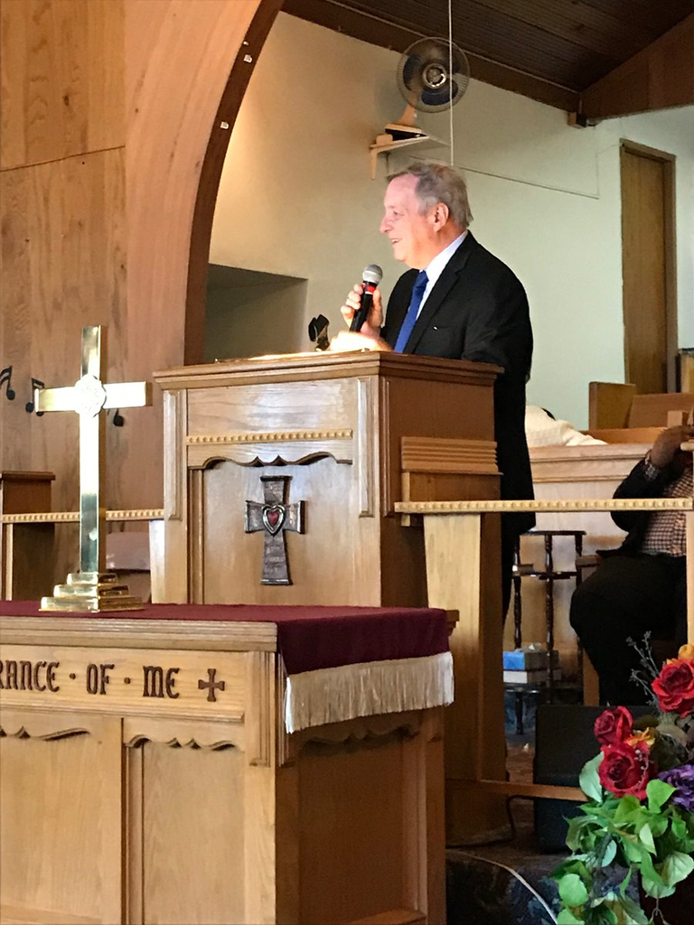

[figure not shown]

```r
## Top Dem Image (Not Run)

# status_media(
#   topmedia.dem[1,],
#   con,
#   update.media.b64 = FALSE,
#   display.image = TRUE
# )

## Top Rep Image (Not Run)

# status_media(
#   topmedia.rep[1,],
#   con,
#   update.media.b64 = FALSE,
#   display.image = TRUE
# )
```

Top Democrat Image

Top Republican Image

The `top_media` and `status_media` have many options for saving and rendering images. See documentation for details.

### Top tweeters democrats and republicans in the last week

```r
toptweeters.dem <- top_tweeters(
  con,
  start.date = Sys.Date()-7,
  where.criteria = "query_users.party = 'democrat'"
)

toptweeters.rep <- top_tweeters(
  con,
  start.date = Sys.Date()-7,
  where.criteria = "query_users.party = 'republican'"
)

toptweeters.dem$description <- gsub("\n"," -- ",toptweeters.dem$description)
toptweeters.dem$location <- gsub("\n"," -- ",toptweeters.dem$location)
toptweeters.rep$description <- gsub("\n"," -- ",toptweeters.rep$description)
toptweeters.rep$location <- gsub("\n"," -- ",toptweeters.rep$location)
knitr::kable(
  data.frame(
    Name = toptweeters.dem$name,
    Location = toptweeters.dem$location,
    Description = toptweeters.dem$description,
    Tweets = toptweeters.dem$n,
    stringsAsFactors = FALSE
  ),
  caption = "Top Democrat Tweeters"
)
```

Top Democrat Tweeters

| Name | Location | Description | Tweets |
| --- | --- | --- | --- |
| Senator Dick Durbin |  | Serving the people of Illinois. Democratic Whip. | 57 |
| Sen. Maggie Hassan |  | New England sports fan, mom, crossword enthusiast, former governor, U.S. Senator for New Hampshire. | 34 |
| Mike Thompson | St. Helena, CA | Rep. Mike Thompson represents California’s 5th Congressional District and chairs the House Gun Violence Prevention Task Force. | 32 |
| Ron Wyden | Oregon | U.S. Senator from Oregon. @SenateFinance Ranking Member. Follow @WydenPress for updates from my staff. Instagram: https://t.co/a6CyBjcD79 | 30 |
| Sherrod Brown | Cleveland, OH | Office of United States Senator Sherrod Brown. Proud to serve Ohio. Tweets from Sherrod signed -SB. | 28 |
| Sen. Debbie Stabenow | Washington, DC | Representing the people from the Great State of Michigan in the United States Senate | 18 |
| Rep. Peter Welch | Vermont and Washington, DC | Official Twitter Account for Congressman Peter Welch, proudly representing the great state of Vermont in the U.S. House of Representatives. | 7 |
| Bill Foster | Naperville, IL | Congressman Bill Foster is a scientist and businessman representing the 11th Congressional District of Illinois | 5 |
| Rep. Donald Payne Jr | www.facebook.com/DonaldPayneJr | Proudly serving New Jersey’s 10th Congressional District | 4 |
| Rep. Susan Davis |  | Proudly representing the 53rd Congressional District of California. Serves on the Committees on Armed Services, Education & Labor, and House Administration. | 4 |

```r
knitr::kable(
  data.frame(
    Name = toptweeters.rep$name,
    Location = toptweeters.rep$location,
    Description = toptweeters.rep$description,
    Tweets = toptweeters.rep$n,
    stringsAsFactors = FALSE
  ),
  caption = "Top Republican Tweeters"
)
```

Top Republican Tweeters

| Name | Location | Description | Tweets |
| --- | --- | --- | --- |
| Senator John Cornyn | Austin, Texas | Personally curated news I find interesting, pics, and opinions. Honored to represent the great state of Texas in the US Senate. RTs =/= endorsements | 105 |
| President Trump | Washington, D.C. | 45th President of the United States of America, @realDonaldTrump. Tweets archived: https://t.co/eVVzoBb3Zr | 70 |
| Rep Andy Biggs | Arizona, USA | Representing the 5th Congressional District of Arizona. | 44 |
| Jim Risch | Boise | U.S. Senator for Idaho | 15 |
| John Joyce |  | Congressman serving the people of Pennsylvania’s 13th district. Fighting everyday for the freedom and prosperity of our nation. #PA13 | 15 |
| Ann Wagner | Ballwin, MO | Official Twitter account for Congresswoman Ann Wagner– proudly Representing the 2nd Congressional District of Missouri https://t.co/6TKCrqRcSw | 12 |
| Senator Rand Paul | Bowling Green, KY | U.S. Senator for Kentucky \| I fight for the Constitution, individual liberty and the freedoms that make this country great. | 11 |
| Rep. Vicky Hartzler | Harrisonville, Missouri | I serve the hardworking Missourians of #MO4. Working to reduce big govt. burden & unleash American spirit. On Armed Services and Agriculture Committees. | 10 |
| Richard Shelby | Tuscaloosa, Alabama | The official Twitter page for U.S. Senator Richard Shelby (R-Ala.) https://t.co/YqOy54UpSf | 9 |
| Dr. Neal Dunn |  | Official government Twitter account for Congressman Neal Dunn (FL-02). | 4 |

### Most liked tweets democrats and republicans in the last week

```r
mostliked.dem <- most_liked(
  con,
  start.date = Sys.Date()-7,
  where.criteria = "query_users.party = 'democrat'"
)

mostliked.rep <- most_liked(
  con,
  start.date = Sys.Date()-7,
  where.criteria = "query_users.party = 'republican'"
)

# For nice Markdown rendering
mostliked.dem$description <- gsub("\n"," -- ",mostliked.dem$description)
mostliked.dem$location <- gsub("\n"," -- ",mostliked.dem$location)
mostliked.dem$text <- gsub("\n"," -- ",mostliked.dem$text)
mostliked.dem$name <- gsub("\n"," -- ",mostliked.dem$name)
mostliked.rep$description <- gsub("\n"," -- ",mostliked.rep$description)
mostliked.rep$location <- gsub("\n"," -- ",mostliked.rep$location)
mostliked.rep$text <- gsub("\n"," -- ",mostliked.rep$text)
mostliked.rep$name <- gsub("\n"," -- ",mostliked.rep$name)
knitr::kable(
  data.frame(
    Name = mostliked.dem$name,
    Created = mostliked.dem$created_at,
    Likes = mostliked.dem$favorite_count,
    Text = mostliked.dem$text,
    stringsAsFactors = FALSE
  ),
  caption = "Most Liked Democrat Tweets"
)
```

Most Liked Democrat Tweets

| Name | Created | Likes | Text |
| --- | --- | --- | --- |
| Senator Dick Durbin | 2019-01-29 23:03:45 | 11164 | The Republican party needs to wake up when it comes to this President and his pro-Russia posturing. We took an oath to defend the United States from enemies foreign and domestic, and it’s time for Con… |
| Senator Dick Durbin | 2019-02-01 18:55:52 | 7904 | This historic drug seizure at a legal port of entry proves wrong nearly every single thing President Trump has said on border security. – – His big beautiful wall is not an effective way to stop the l… |
| Senator Dick Durbin | 2019-01-31 15:22:42 | 5877 | The reports about the alleged hate crime against Jussie Smollett in Chicago are horrific, and I wish him a quick and full recovery. Our nation must address the significant, ongoing threat of violence … |
| Mike Thompson | 2019-01-31 11:45:11 | 3892 | 🚨🚨Breaking News: The House will hold the first hearing on gun violence prevention in eight years! Stay tuned next Wednesday, February 6 at 10am ET because the House is finally taking action to prevent… |
| Senator Dick Durbin | 2019-01-28 02:50:45 | 2769 | Air traffic controllers had to weather the President’s 35 day government shutdown. These women and men are critical to our safety, and they didn’t deserve to be punished. I thanked them for their serv… |
| Ron Wyden | 2019-02-01 18:41:16 | 2549 | America is learning what Oregonians already know: there is growing evidence that Saudi Arabia is aiding and abetting Saudi nationals who are committing violent crimes on American soil, and abusing mod… |
| Ron Wyden | 2019-01-26 01:53:42 | 2093 | You forced hundreds of thousands of families to go without paychecks and access to vital government services. You made millions of Americans suffer to help Trump secure a racist talking point. https:/… |
| Bill Foster | 2019-01-29 02:59:12 | 1428 | Again, please talk to a scientist. https://t.co/9ZYP0X7QxD |
| Ron Wyden | 2019-01-28 20:05:18 | 1345 | \|￣￣￣￣￣￣\| – \| Protect \| – \| Americans’ \| – \| Privacy \| – \| ＿＿＿＿＿*\| – (_*/) \|\| – (•ㅅ•) \|\| – / づ – – #DataPrivacyDay |
| Senator Dick Durbin | 2019-01-28 21:21:11 | 1209 | Don’t be fooled by the President’s tweets. The nonpartisan CBO tells us that his scorched-Earth trade policy comes with a cost. American consumers, businesses, and farmers will feel the brunt of it. h… |

```r
knitr::kable(
  data.frame(
    Name = mostliked.rep$name,
    Created = mostliked.rep$created_at,
    Likes = mostliked.rep$favorite_count,
    Text = mostliked.rep$text,
    stringsAsFactors = FALSE
  ),
  caption = "Most Liked Republican Tweets"
)
```

Most Liked Republican Tweets

| Name | Created | Likes | Text |
| --- | --- | --- | --- |
| Senator Rand Paul | 2019-02-01 03:17:01 | 39920 | He’s not wrong: Suddenly, when we finally have a President trying to end wars and withdraw troops, the Senate miraculously rallies to act, to wrongly try to stop wars from ending. https://t.co/YVR57kH… |
| Senator Rand Paul | 2019-02-01 14:27:52 | 25112 | We stand with you @realDonaldTrump! Time to declare victory, end these wars and focus on rebuilding our own homeland. Don’t listen to the naysayers in the swamp, you are making the right decision! htt… |
| Senator Rand Paul | 2019-01-30 23:18:31 | 15752 | This lawsuit wasn’t about me. It was about all of us and what we find acceptable as a society. We need to send a clear message that violence is not the answer - anytime, anywhere. – – We can hold diff… |
| Senator Rand Paul | 2019-01-31 17:39:03 | 14671 | I stand with @realDonaldTrump. It is time to bring our troops home from Afghanistan and Syria. It is ludicrous to call withdrawal after 17 years “precipitous.” https://t.co/IKMjOruKP1 |
| Senator Rand Paul | 2019-01-28 13:43:13 | 8608 | “Those who still care about fiscal responsibility should hope the number of liberty Republicans grows.” https://t.co/084GFHkGc1 |
| Senator Rand Paul | 2019-01-30 23:18:32 | 5127 | It’s never ok to turn those disagreements into violent, aggressive anger. I hope that’s the message from today. |
| Rep Andy Biggs | 2019-01-28 15:10:44 | 5083 | .@POTUS @realDonaldTrump soon faces a decision on how to secure America’s border. I believe he should declare the border is an active drug trafficking corridor, pursuant to Title 10 of U.S. Code, whic… |
| Senator Rand Paul | 2019-01-29 14:38:08 | 4031 | The persecution of Christians must stop everywhere around the world. It is time for Pakistan to let Asia Bibi go. The Supreme Court of Pakistan has now reaffirmed her innocence. Her safety is paramoun… |
| Senator Rand Paul | 2019-01-30 13:52:50 | 2535 | Representing Kentucky in Congress is one of my greatest honors. It’d be an abdication of duty and belie all of my deeply held principles if I didn’t stand up for the responsible use of your tax dollar… |
| Senator Rand Paul | 2019-02-01 21:51:51 | 1816 | For months, I worked directly with President Donald Trump and Secretary Acosta to make this happen. I’m happy to see the results. https://t.co/ei9WSzOJmg |

### Most retweeted tweets democrats and republicans in the last week

```r
mostretweeted.dem <- most_retweeted(
  con,
  start.date = Sys.Date()-7,
  where.criteria = "query_users.party = 'democrat'"
)

mostretweeted.rep <- most_retweeted(
  con,
  start.date = Sys.Date()-7,
  where.criteria = "query_users.party = 'republican'"
)

# For nice Markdown rendering
mostretweeted.dem$description <- gsub("\n"," -- ",mostretweeted.dem$description)
mostretweeted.dem$location <- gsub("\n"," -- ",mostretweeted.dem$location)
mostretweeted.dem$text <- gsub("\n"," -- ",mostretweeted.dem$text)
mostretweeted.dem$name <- gsub("\n"," -- ",mostretweeted.dem$name)
mostretweeted.rep$description <- gsub("\n"," -- ",mostretweeted.rep$description)
mostretweeted.rep$location <- gsub("\n"," -- ",mostretweeted.rep$location)
mostretweeted.rep$text <- gsub("\n"," -- ",mostretweeted.rep$text)
mostretweeted.rep$name <- gsub("\n"," -- ",mostretweeted.rep$name)
knitr::kable(
  data.frame(
    Name = mostretweeted.dem$name,
    Created = mostretweeted.dem$created_at,
    Retweet_Count = mostretweeted.dem$retweet_count,
    Text = mostretweeted.dem$text,
    stringsAsFactors = FALSE
  ),
  caption = "Most Retweeted Democrat Tweets"
)
```

Most Retweeted Democrat Tweets

| Name | Created | Retweet_Count | Text |
| --- | --- | --- | --- |
| Senator Dick Durbin | 2019-01-29 23:03:45 | 4512 | The Republican party needs to wake up when it comes to this President and his pro-Russia posturing. We took an oath to defend the United States from enemies foreign and domestic, and it’s time for Con… |
| Senator Dick Durbin | 2019-02-01 18:55:52 | 3054 | This historic drug seizure at a legal port of entry proves wrong nearly every single thing President Trump has said on border security. – – His big beautiful wall is not an effective way to stop the l… |
| Ron Wyden | 2019-02-01 18:41:16 | 1707 | America is learning what Oregonians already know: there is growing evidence that Saudi Arabia is aiding and abetting Saudi nationals who are committing violent crimes on American soil, and abusing mod… |
| Mike Thompson | 2019-01-31 11:45:11 | 1382 | 🚨🚨Breaking News: The House will hold the first hearing on gun violence prevention in eight years! Stay tuned next Wednesday, February 6 at 10am ET because the House is finally taking action to prevent… |
| Senator Dick Durbin | 2019-01-31 15:22:42 | 1381 | The reports about the alleged hate crime against Jussie Smollett in Chicago are horrific, and I wish him a quick and full recovery. Our nation must address the significant, ongoing threat of violence … |
| Ron Wyden | 2019-01-26 01:53:42 | 716 | You forced hundreds of thousands of families to go without paychecks and access to vital government services. You made millions of Americans suffer to help Trump secure a racist talking point. https:/… |
| Senator Dick Durbin | 2019-01-28 02:50:45 | 622 | Air traffic controllers had to weather the President’s 35 day government shutdown. These women and men are critical to our safety, and they didn’t deserve to be punished. I thanked them for their serv… |
| Ron Wyden | 2019-01-31 22:35:24 | 621 | It is deeply troubling that individuals closely associated with the Trump campaign appear to have used shady, likely illegal tactics to undermine #NetNeutrality and to deprive Americans of internet fr… |
| Ron Wyden | 2019-01-30 16:28:49 | 582 | Any claims that the NRA played no official role in the 2015 Moscow trip are not credible. https://t.co/qu8YYdtN7b |
| Senator Dick Durbin | 2019-01-28 21:21:11 | 528 | Don’t be fooled by the President’s tweets. The nonpartisan CBO tells us that his scorched-Earth trade policy comes with a cost. American consumers, businesses, and farmers will feel the brunt of it. h… |

```r
knitr::kable(
  data.frame(
    Name = mostretweeted.rep$name,
    Created = mostretweeted.rep$created_at,
    Retweet_Count = mostretweeted.rep$retweet_count,
    Text = mostretweeted.rep$text,
    stringsAsFactors = FALSE
  ),
  caption = "Most Retweeted Republican Tweets"
)
```

Most Retweeted Republican Tweets

| Name | Created | Retweet_Count | Text |
| --- | --- | --- | --- |
| Senator Rand Paul | 2019-02-01 03:17:01 | 15317 | He’s not wrong: Suddenly, when we finally have a President trying to end wars and withdraw troops, the Senate miraculously rallies to act, to wrongly try to stop wars from ending. https://t.co/YVR57kH… |
| Senator Rand Paul | 2019-02-01 14:27:52 | 7659 | We stand with you @realDonaldTrump! Time to declare victory, end these wars and focus on rebuilding our own homeland. Don’t listen to the naysayers in the swamp, you are making the right decision! htt… |
| Senator Rand Paul | 2019-01-31 17:39:03 | 4663 | I stand with @realDonaldTrump. It is time to bring our troops home from Afghanistan and Syria. It is ludicrous to call withdrawal after 17 years “precipitous.” https://t.co/IKMjOruKP1 |
| Senator Rand Paul | 2019-01-30 23:18:31 | 3808 | This lawsuit wasn’t about me. It was about all of us and what we find acceptable as a society. We need to send a clear message that violence is not the answer - anytime, anywhere. – – We can hold diff… |
| Senator Rand Paul | 2019-01-28 13:43:13 | 2134 | “Those who still care about fiscal responsibility should hope the number of liberty Republicans grows.” https://t.co/084GFHkGc1 |
| Rep Andy Biggs | 2019-01-28 15:10:44 | 1772 | .@POTUS @realDonaldTrump soon faces a decision on how to secure America’s border. I believe he should declare the border is an active drug trafficking corridor, pursuant to Title 10 of U.S. Code, whic… |
| Senator Rand Paul | 2019-01-29 14:38:08 | 1230 | The persecution of Christians must stop everywhere around the world. It is time for Pakistan to let Asia Bibi go. The Supreme Court of Pakistan has now reaffirmed her innocence. Her safety is paramoun… |
| Senator Rand Paul | 2019-01-30 23:18:32 | 908 | It’s never ok to turn those disagreements into violent, aggressive anger. I hope that’s the message from today. |
| Senator Rand Paul | 2019-02-01 21:51:51 | 549 | For months, I worked directly with President Donald Trump and Secretary Acosta to make this happen. I’m happy to see the results. https://t.co/ei9WSzOJmg |
| Senator Rand Paul | 2019-01-30 13:52:50 | 539 | Representing Kentucky in Congress is one of my greatest honors. It’d be an abdication of duty and belie all of my deeply held principles if I didn’t stand up for the responsible use of your tax dollar… |

## Most popular retweet in sample

```r
mostpopRT.dem <- most_popular_RT_in_sample(
  con,
  start.date = Sys.Date()-7,
  where.criteria = "query_users.party = 'democrat'"
)

mostpopRT.rep <- most_popular_RT_in_sample(
  con,
  start.date = Sys.Date()-7,
  where.criteria = "query_users.party = 'republican'"
)

# For nice Markdown rendering
mostpopRT.dem$description <- gsub("\n"," -- ",mostpopRT.dem$description)
mostpopRT.dem$location <- gsub("\n"," -- ",mostpopRT.dem$location)
mostpopRT.dem$text <- gsub("\n"," -- ",mostpopRT.dem$text)
mostpopRT.dem$name <- gsub("\n"," -- ",mostpopRT.dem$name)
mostpopRT.rep$description <- gsub("\n"," -- ",mostpopRT.rep$description)
mostpopRT.rep$location <- gsub("\n"," -- ",mostpopRT.rep$location)
mostpopRT.rep$text <- gsub("\n"," -- ",mostpopRT.rep$text)
mostpopRT.rep$name <- gsub("\n"," -- ",mostpopRT.rep$name)
knitr::kable(
  data.frame(
    Name = mostpopRT.dem$name,
    Created = mostpopRT.dem$created_at,
    Dem_Retweets = mostpopRT.dem$n,
    Text = mostpopRT.dem$text,
    stringsAsFactors = FALSE
  ),
  caption = "Most Popular Retweets Among Democrats"
)
```

Most Popular Retweets Among Democrats

| Name | Created | Dem_Retweets | Text |
| --- | --- | --- | --- |
| Michigan Great Lakes | 2019-01-28 17:30:09 | 1 | What’s a little snow when you’re working to #ENDALZ? Thanks to our incredibly dedicated #volunteers for meeting with @SenStabenow this morning to talk about ways we can continue to work together to im… |
| Ready Illinois | 2019-01-28 21:46:59 | 1 | 🌬RECORD COLD 🌬: A wind chill watch has been issued from Tuesday PM - Thursday AM. With these temperatures, frostbite can set in within 5 minutes. – ⌚️❄️Limit your time outside – 🧥🧣🧤Dress in Layers – 🐶… |
| Governor JB Pritzker | 2019-01-28 23:59:03 | 1 | IDHS offices also serve as warming centers for anyone looking to find a safe, warm place to go during the cold. To find a full list of warming centers, visit https://t.co/wGlH7KZXfi. |
| Oversight Committee | 2019-01-29 14:31:34 | 1 | 📺TUNE IN at 11 AM EST for the Committee’s 1st hearing of the 116th Congress on examining the actions of drug companies in raising #prescriptiondrugprices. https://t.co/uakYfw2gBF |
| NOAA Climate.gov | 2019-01-29 15:00:23 | 1 | Winter storms don’t prove that global warming isn’t happening. – https://t.co/LDqfq4JH9n https://t.co/ndmLD637Cb |
| City of Akron, Ohio | 2019-01-29 21:26:50 | 1 | Stay warm and stay safe! Here are some good precautions to safely heat your home during these extreme temperatures. https://t.co/UBedCWf81l |
| Fred Guttenberg | 2019-01-29 22:02:20 | 1 | It was my honor to be able to meet and talk about #HR8 with you @RepThompson Thank you for your leadership on this bill. Lives will be saved because of it. https://t.co/g2vnzgSHBr |
| IllinoisStatePolice | 2019-01-29 17:25:36 | 1 | Life-threatening arctic cold temperatures this evening through Thursday morning. – – 🥶Avoid time outdoors if possible – – 🥶Cover exposed skin – – 🥶Layer clothing, hats and gloves – – 🥶Know the signs o… |
| Rosa DeLauro | 2019-01-30 12:30:00 | 1 | Women and men doing the same job deserve the same pay—period. That’s why Congress needs to pass the #PaycheckFairness Act. Tune in as I reintroduce it with @SpeakerPelosi, leading Democrats, and natio… |
| IllinoisStatePolice | 2019-01-30 13:52:22 | 1 | 🚨🚔⚠️ – – Troopers are clearing their patrol areas to look for stranded motorists. – – If you become stranded in these life-threatening temperatures, stay inside your vehicle and call 911. – – #PolarVo… |

```r
knitr::kable(
  data.frame(
    Name = mostpopRT.rep$name,
    Created = mostpopRT.rep$created_at,
    Rep_Retweets = mostpopRT.rep$n,
    Text = mostpopRT.rep$text,
    stringsAsFactors = FALSE
  ),
  caption = "Most Popular Retweets Among Republicans"
)
```

Most Popular Retweets Among Republicans

| Name | Created | Rep_Retweets | Text |
| --- | --- | --- | --- |
| HouseVetAffairsGOP | 2019-01-28 23:03:36 | 2 | This Monday, we just want to say thank you to all our #veterans! If you have a chance, thank a veteran today. https://t.co/66a0eA81FA |
| Donald J. Trump | 2019-02-01 13:23:07 | 2 | I inherited a total mess in Syria and Afghanistan, the “Endless Wars” of unlimited spending and death. During my campaign I said, very strongly, that these wars must finally end. We spend $50 Billion … |
| Donald J. Trump | 2019-01-26 00:33:50 | 1 | I wish people would read or listen to my words on the Border Wall. This was in no way a concession. It was taking care of millions of people who were getting badly hurt by the Shutdown with the unders… |
| Donald J. Trump | 2019-01-26 13:42:28 | 1 | If Roger Stone was indicted for lying to Congress, what about the lying done by Comey, Brennan, Clapper, Lisa Page & lover, Baker and soooo many others? What about Hillary to FBI and her 33,000 delete… |
| Donald J. Trump | 2019-01-26 14:01:48 | 1 | 21 days goes very quickly. Negotiations with Democrats will start immediately. Will not be easy to make a deal, both parties very dug in. The case for National Security has been greatly enhanced by wh… |
| Donald J. Trump | 2019-01-26 14:06:39 | 1 | We have turned away, at great expense, two major Caravans, but a big one has now formed and is coming. At least 8000 people! If we had a powerful Wall, they wouldn’t even try to make the long and dang… |
| Donald J. Trump | 2019-01-26 14:23:29 | 1 | Thank you to the Republican National Committee, (the RNC), who voted UNANIMOUSLY yesterday to support me in the upcoming 2020 Election. Considering that we have done more than any Administration in th… |
| Donald J. Trump | 2019-01-26 14:32:46 | 1 | “We absolutely need a physical barrier or Wall, whatever you want to call it. The President yesterday laid all that out. We need to do it all, including the Wall. I provided the same information to th… |
| Donald J. Trump | 2019-01-26 16:42:32 | 1 | BUILD A WALL & CRIME WILL FALL! https://t.co/a0G7GWi74k |
| Gilbert, Arizona | 2019-01-25 22:44:01 | 1 | Tonight through Tuesday, January 29th, Gilbert’s Water Tower will be lit up blue in remembrance of Lieutenant Eric Shuhandler, who was killed nine years ago in the line of duty. – – His service to our… |

### Most reach

Note: this metric is of dubious value. See documentation.

```r
mostreach.dem <- most_reach(
  con,
  start.date = Sys.Date()-7,
  where.criteria = "query_users.party = 'democrat'"
)
mostreach.rep <- most_reach(
  con,
  start.date = Sys.Date()-7,
  where.criteria = "query_users.party = 'republican'"
)
# For nice Markdown rendering
mostreach.dem$description <- gsub("\n"," -- ",mostreach.dem$description)
mostreach.dem$location <- gsub("\n"," -- ",mostreach.dem$location)
mostreach.dem$text <- gsub("\n"," -- ",mostreach.dem$text)
mostreach.dem$name <- gsub("\n"," -- ",mostreach.dem$name)
mostreach.rep$description <- gsub("\n"," -- ",mostreach.rep$description)
mostreach.rep$location <- gsub("\n"," -- ",mostreach.rep$location)
mostreach.rep$text <- gsub("\n"," -- ",mostreach.rep$text)
mostreach.rep$name <- gsub("\n"," -- ",mostreach.rep$name)
knitr::kable(
  data.frame(
    Name = mostreach.dem$name,
    Created = mostreach.dem$created_at,
    Reach = mostreach.dem$n,
    Text = mostreach.dem$text,
    stringsAsFactors = FALSE
  ),
  caption = "Democrat Tweets with Most 'Reach'"
)
```

Democrat Tweets with Most ‘Reach’

| Name | Created | Reach | Text |
| --- | --- | --- | --- |
| Ready Illinois | 2019-01-28 21:46:59 | 589364 | 🌬RECORD COLD 🌬: A wind chill watch has been issued from Tuesday PM - Thursday AM. With these temperatures, frostbite can set in within 5 minutes. – ⌚️❄️Limit your time outside – 🧥🧣🧤Dress in Layers – 🐶… |
| Senator Dick Durbin | 2019-01-29 20:35:45 | 589364 | On the 2nd anniversary of the President’s travel ban, I joined @SenBlumenthal to introduce a resolution that calls for a recommitment to America’s tradition of providing safe haven to the world’s most… |
| Senator Dick Durbin | 2019-01-29 23:03:45 | 589364 | The Republican party needs to wake up when it comes to this President and his pro-Russia posturing. We took an oath to defend the United States from enemies foreign and domestic, and it’s time for Con… |
| Senator Dick Durbin | 2019-01-30 00:45:37 | 589364 | I’m glad @SenDuckworth, @RepLipinski, @RepBillFoster, @RepSchneider, and @RepCasten could join me today. |
| Senator Dick Durbin | 2019-01-30 22:13:23 | 589364 | 10 years after the signing of the Lilly Ledbetter Fair Pay Act, women in the workforce continue to face pay inequalities. This is why I support the #PaycheckFairnessAct. It’s time to close the gender … |
| Chicago Cubs | 2019-01-31 14:00:50 | 589364 | There’s only one Mr. Cub. 🐻💙 – – Happy birthday to Ernie Banks! #LetsPlayTwo https://t.co/RGsrsd67MS |
| Senator Dick Durbin | 2019-01-31 16:23:19 | 589364 | At the first meeting of the homeland security conferees yesterday, I urged my colleagues on both sides of the aisle to focus on smart and effective border security measures as opposed to threats of go… |
| Smithsonian NMAAHC | 2019-02-01 13:21:24 | 589364 | Between the 1400s and the 1800s, at least 12M people were trafficked from Africa to the Americas. Over a century later, the transition from slavery to freedom is symbolized by The Great Migration. – –… |
| Senator Dick Durbin | 2019-02-01 15:29:08 | 589364 | I’ve met Juan Guaidó and have seen his love for the people of Venezuela. He can foster the desperately needed change as called for by the region’s democratic nations and provided for in the Venezuelan… |
| Senator Dick Durbin | 2019-02-01 21:57:25 | 589364 | As a new member of @SenateAgDems I was happy to discuss various agricultural issues with the @ILFarmBureau today in Bloomington. https://t.co/8rgdn7KoMb |

```r
knitr::kable(
  data.frame(
    Name = mostreach.rep$name,
    Created = mostreach.rep$created_at,
    Reach = mostreach.rep$n,
    Text = mostreach.rep$text,
    stringsAsFactors = FALSE
  ),
  caption = "Republican Tweets with Most 'Reach'"
)
```

Republican Tweets with Most ‘Reach’

| Name | Created | Reach | Text |
| --- | --- | --- | --- |
| Donald J. Trump | 2019-02-01 13:23:07 | 27515264 | I inherited a total mess in Syria and Afghanistan, the “Endless Wars” of unlimited spending and death. During my campaign I said, very strongly, that these wars must finally end. We spend $50 Billion … |
| Donald J. Trump | 2019-01-26 00:33:50 | 25086318 | I wish people would read or listen to my words on the Border Wall. This was in no way a concession. It was taking care of millions of people who were getting badly hurt by the Shutdown with the unders… |
| Donald J. Trump | 2019-01-27 15:11:55 | 25086318 | Jens Stoltenberg, NATO Secretary General, just stated that because of me NATO has been able to raise far more money than ever before from its members after many years of decline. It’s called burden sh… |
| Donald J. Trump | 2019-01-28 13:50:11 | 25086318 | “In the Media’s effort to destroy the President, they are actually destroying themselves. Given all of the tremendous headwinds this President has faced, it’s amazing he has accomplished so much.” DER… |
| Donald J. Trump | 2019-01-29 02:46:02 | 25086318 | How does Da Nang Dick (Blumenthal) serve on the Senate Judiciary Committee when he defrauded the American people about his so called War Hero status in Vietnam, only to later admit, with tears pouring… |
| Donald J. Trump | 2019-01-30 11:02:54 | 25086318 | Maduro willing to negotiate with opposition in Venezuela following U.S. sanctions and the cutting off of oil revenues. Guaido is being targeted by Venezuelan Supreme Court. Massive protest expected to… |
| The White House | 2019-01-30 16:39:00 | 25086318 | “The border wall should be not about power and partisan politics. It should be about the children – the tens of thousands of them who have been and are being trafficked into the U.S. and forced into t… |
| The White House | 2019-01-30 19:43:02 | 25086318 | More than 3 million people have fled Venezuela since 2015. The United Nations estimates that number may swell to 5.3 million by the end of 2019. – – The United States stands with Venezuelans as they d… |
| Donald J. Trump | 2019-01-30 21:54:12 | 25086318 | Dow just broke 25,000. Tremendous news! |
| Donald J. Trump | 2019-01-31 13:21:01 | 25086318 | Republicans on the Homeland Security Committee are wasting their time. Democrats, despite all of the evidence, proof and Caravans coming, are not going to give money to build the DESPERATELY needed WA… |

### Word clouds

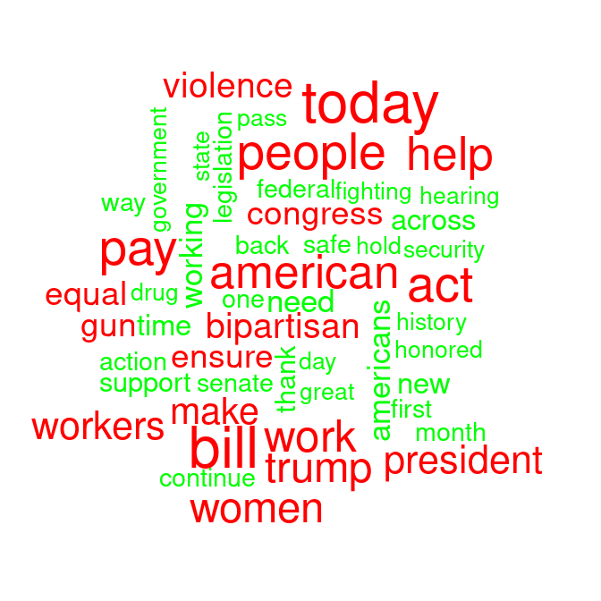

```r
wordcloud_plot(
  con,
  start.date = Sys.Date()-7,
  where.criteria = "query_users.party = 'democrat'",
  caption = "Democrats"
)
```

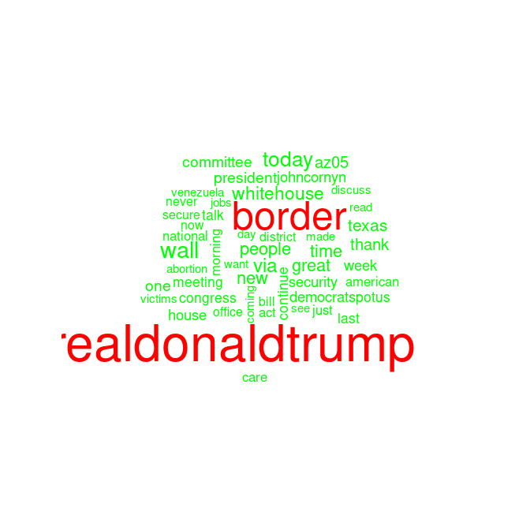

```r
wordcloud_plot(
  con,
  start.date = Sys.Date()-7,
  where.criteria = "query_users.party = 'republican'",
  caption = "Republicans"
)
```

### Sentiment plots

Note these are saved to files.

```r
sentiment_plots(
  con,
  start.date = Sys.Date()-7,
  where.criteria = "query_users.party = 'democrat'",
  file.name.prefix = "Dem",
  caption = "Democrats"
)
```

```
#>          Sentiment       Date Percentage
#> 1         positive 2019-01-26  57.142857
#> 2  slight positive 2019-01-26   0.000000
#> 3          neutral 2019-01-26  14.285714
#> 4  slight negative 2019-01-26   0.000000
#> 5         negative 2019-01-26  28.571429
#> 6          unknown 2019-01-26   0.000000
#> 7         positive 2019-01-27  71.428571
#> 8  slight positive 2019-01-27  14.285714
#> 9          neutral 2019-01-27  14.285714
#> 10 slight negative 2019-01-27   0.000000
#> 11        negative 2019-01-27   0.000000
#> 12         unknown 2019-01-27   0.000000
#> 13        positive 2019-01-28  30.000000
#> 14 slight positive 2019-01-28  20.000000
```

[output cut: 40 more lines]

```
#>          Sentiment       Date Percentage
#> 1         positive 2019-01-26   0.000000
#> 2  slight positive 2019-01-26  28.571429
#> 3          neutral 2019-01-26  42.857143
#> 4  slight negative 2019-01-26  14.285714
#> 5         negative 2019-01-26  14.285714
#> 6          unknown 2019-01-26   0.000000
#> 7         positive 2019-01-27  11.111111
#> 8  slight positive 2019-01-27  33.333333
#> 9          neutral 2019-01-27   0.000000
#> 10 slight negative 2019-01-27  22.222222
#> 11        negative 2019-01-27  22.222222
#> 12         unknown 2019-01-27  11.111111
#> 13        positive 2019-01-28  31.818182
#> 14 slight positive 2019-01-28  31.818182
```

[output cut: 40 more lines]

[figure not shown]

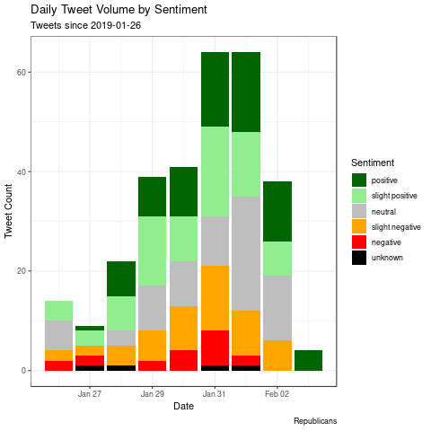

```r
sentiment_plots(
  con,
  start.date = Sys.Date()-7,
  where.criteria = "query_users.party = 'republican'",
  file.name.prefix = "Rep",
  caption = "Republicans"
)
```

Democrat Absolute Sentiment

Republican Absolute Sentiment

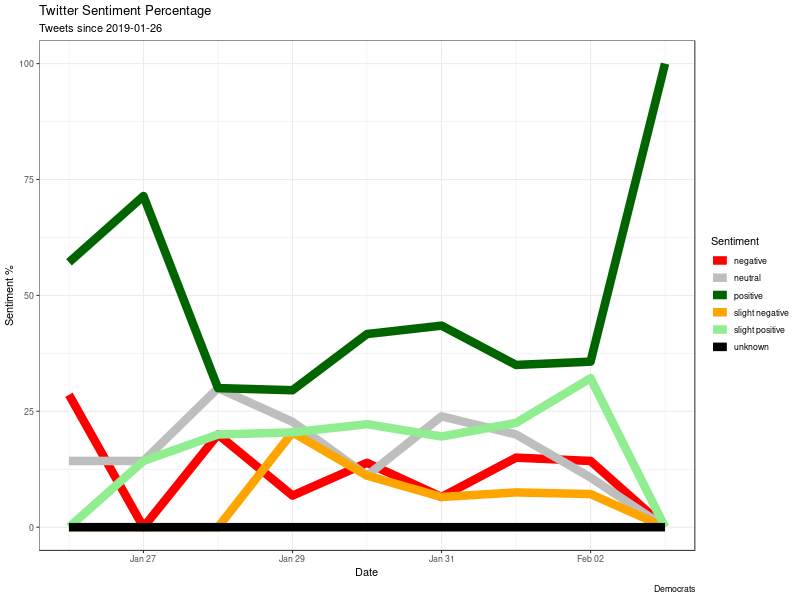

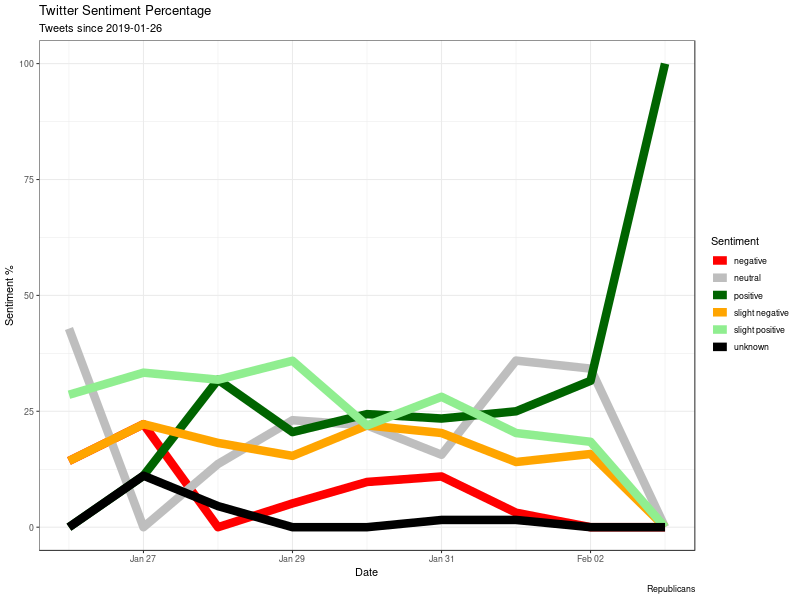

Democrat Relative Sentiment

Republican Relative Sentiment

### Tweet timeplot

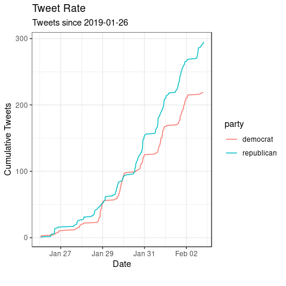

```r
timeplot(
  con,
  start.date = Sys.Date()-7,
  where.criteria = "query_users.party = 'republican' OR query_users.party = 'democrat'",
  group.column = "query_users.party"
)
```

### Friend network analysis and some nice network plots

```r
# Import igraph
library(igraph)
# Custom database queries and graph creation.
edgelist.query <- "SELECT query_users_fo.screen_name as follower, query_users_fr.screen_name as friend, query_users_fo.party as follower_party, query_users_fr.party as friend_party FROM query_users as query_users_fo JOIN followers ON query_users_fo.user_id = followers.follower_id JOIN query_users AS query_users_fr ON followers.friend_id = query_users_fr.user_id;"
edgelist.df <- DBI::dbGetQuery(con,edgelist.query)
g <- graph_from_data_frame(edgelist.df)
vertices.df <- data.frame(index=as.integer(V(g)), screen_name = names(V(g)),stringsAsFactors = FALSE)
vertex.query <- sprintf("SELECT query_users.screen_name,query_users.party,query_users.body,user.name,user.location,user.description,user.followers_count,user.statuses_count FROM query_users JOIN user ON query_users.user_id = user.id WHERE query_users.screen_name IN (%s);",paste("'",vertices.df$screen_name,"'",sep="",collapse=","))
vertex.query.df <- DBI::dbGetQuery(con,vertex.query)
vertex.query.df <- vertex.query.df[match(vertices.df$screen_name,vertex.query.df$screen_name),]

bluered <- function(party){
  if(tolower(party)=="democrat"){
    return("blue")
  } else if(tolower(party)=="republican"){
    return("red")
  } else {
    return("black")
  }
}

vertex.query.df$color <- sapply(vertex.query.df$party,bluered)
```

#### Eigenvector Centrality

```r
 ec <- centr_eigen(g,directed=FALSE)
 df <- data.frame(
  Screen_Name = paste(
    "@",
    vertex.query.df$screen_name,
    sep=""
  ),
  Eig_Centrality = as.numeric(ec$vector)
 )
 df <- df[order(df[,2],decreasing=TRUE),]
 knitr::kable(
  df[1:10,],
  row.names = FALSE,
  caption = "Friend Network Eigenvector Centrality"
 )
```

Friend Network Eigenvector Centrality

| Screen_Name | Eig_Centrality |
| --- | --- |
| @SenatorDurbin | 1.0000000 |
| @SenSherrodBrown | 0.9365833 |
| @RonWyden | 0.8652212 |
| @JohnCornyn | 0.8542140 |
| @SenatorHassan | 0.7747285 |
| @SenShelby | 0.7559620 |
| @SenatorRisch | 0.7007423 |
| @RepBillFoster | 0.6918183 |
| @SenStabenow | 0.6859668 |
| @RandPaul | 0.6010371 |

#### Betweenness centrality

```r
bc <- centr_betw(g,directed=FALSE)
df <- data.frame(
  Screen_Name = paste(
    "@",
    vertex.query.df$screen_name,
    sep=""
  ),
  Bet_Centrality = as.numeric(bc$res)
)
df <- df[order(df[,2],decreasing=TRUE),]
knitr::kable(
  df[1:10,],
  row.names = FALSE,
  caption = "Friend Network Betweenness Centrality"
)
```

Friend Network Betweenness Centrality

| Screen_Name | Bet_Centrality |
| --- | --- |
| @RepBillFoster | 28.081649 |
| @POTUS | 19.239408 |
| @RepAnnWagner | 14.748717 |
| @SenatorDurbin | 9.088567 |
| @RandPaul | 8.240201 |
| @RepHartzler | 8.202320 |
| @JohnCornyn | 7.629765 |
| @SenSherrodBrown | 6.914404 |
| @PeterWelch | 6.158814 |
| @SenShelby | 3.017941 |

#### Clustering (label propagation)

```r
clust.labelprop <- cluster_label_prop(as.undirected(g))
clust.labelprop
```

```
#> IGRAPH clustering label propagation, groups: 1, mod: 0
#> + groups:
#>   $`1`
#>    [1] "RepAndyBiggsAZ"  "DrNealDunnFL2"   "RepHartzler"
#>    [4] "RepAnnWagner"    "JohnCornyn"      "SenShelby"
#>    [7] "RandPaul"        "SenatorRisch"    "SASCMajority"
#>   [10] "RepDonaldPayne"  "PeterWelch"      "RepBillFoster"
#>   [13] "SenSherrodBrown" "RepSusanDavis"   "RonWyden"
#>   [16] "SenatorHassan"   "SenatorDurbin"   "SenStabenow"
#>   [19] "POTUS"           "RepThompson"
#>
```

#### Visualize

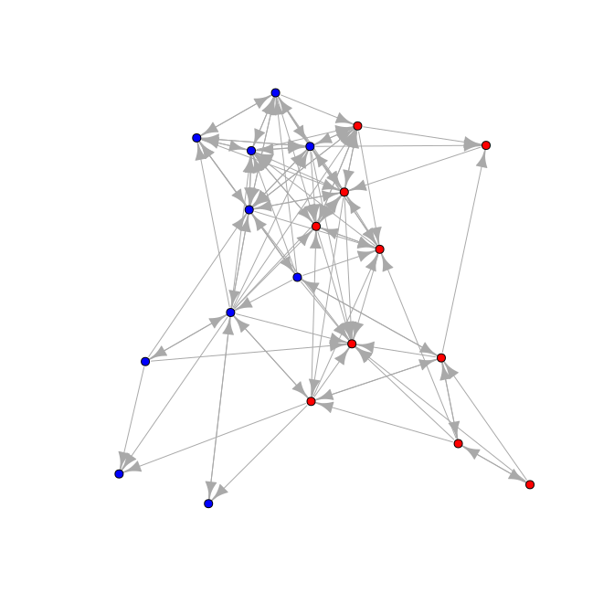

```r
verts <- data.frame(
    name = vertex.query.df$screen_name,
    label = vertex.query.df$screen_name,
    title = vertex.query.df$name,
    color = vertex.query.df$color,
    stringsAsFactors = FALSE
)

for(n in names(verts)){
  g <- set_vertex_attr(g,n,value=verts[,n])
}

plot(g,vertex.color=vertex_attr(g,"color"),vertex.size=4,vertex.label=NA)
```

#### Interactive visualization with sigmajs

```r
# Not run
library(sigmajs)
```

```r
s <- sigmajs()
s <- sg_from_igraph(s,g)
s <- sg_settings(s,defaultEdgeColor="#AAA", edgeColor="default",minNodeSize=1,maxNodeSize=4)
s
```

[interactive chart not shown]

#### Interactive visualization with visNetwork

```r
# Not Run
library(visNetwork)
v <- visIgraph(g)
v <- visEdges(
  v,
  color="gray"
)
v <- visNodes(
  v,
  size = 10
)
v
```

[interactive chart not shown]

### User mention network analysis

This is essentially the same analysis as above, but using the user mention network.

```r
usermention.query <- sprintf("SELECT query_users_mentioner.screen_name as mentioner,query_users_mentioned.screen_name as mentioned, status.id as status_id, status.text as status_text, status.created_at as created_at FROM query_users as query_users_mentioner JOIN status ON query_users_mentioner.user_id = status.user_id JOIN user_mention ON status.id = user_mention.status_id JOIN query_users as query_users_mentioned ON user_mention.user_mention_id = query_users_mentioned.user_id WHERE status.created_at > '%s';",format(Sys.Date()-7))
usermentions.df <- DBI::dbGetQuery(con,usermention.query)
if(nrow(usermentions.df) > 0){
  g <- graph_from_data_frame(usermentions.df)
  vertices.df <- data.frame(index=as.integer(V(g)), screen_name = names(V(g)),stringsAsFactors = FALSE)
  vertex.query <- sprintf("SELECT query_users.screen_name,query_users.party,query_users.body,user.name,user.location,user.description,user.followers_count,user.statuses_count FROM query_users JOIN user ON query_users.user_id = user.id WHERE query_users.screen_name IN (%s);",paste("'",vertices.df$screen_name,"'",sep="",collapse=","))
  vertex.query.df <- DBI::dbGetQuery(con,vertex.query)
  vertex.query.df <- vertex.query.df[match(vertices.df$screen_name,vertex.query.df$screen_name),]

  bluered <- function(party){
    if(tolower(party)=="democrat"){
      return("#DDDDFF")
    } else if(tolower(party)=="republican"){
      return("#FFDDDD")
    } else {
      return("black")
    }
  }

  vertex.query.df$color <- sapply(vertex.query.df$party,bluered)
}
```

#### Eigenvector Centrality

```r
if(nrow(usermentions.df) > 0){
  ec <- centr_eigen(g,directed=FALSE)
  df <- data.frame(
    Screen_Name = paste(
      "@",
      vertex.query.df$screen_name,
      sep=""
    ),
    Eig_Centrality = as.numeric(ec$vector)
  )
  df <- df[order(df[,2],decreasing=TRUE),]
  knitr::kable(
    df[1:10,],
    row.names = FALSE,
    caption = "User Mention Network Eigenvector Centrality"
  )
}
```

User Mention Network Eigenvector Centrality

| Screen_Name | Eig_Centrality |
| --- | --- |
| @JohnCornyn | 1 |
| @RonWyden | 0 |
| @SenatorDurbin | 0 |
| @SenSherrodBrown | 0 |
| @RepAnnWagner | 0 |
| @RepJohnJoyce | 0 |
| @PeterWelch | 0 |
| @DrNealDunnFL2 | 0 |
| @RepThompson | 0 |
| @SenStabenow | 0 |

#### Betweenness centrality

```r
if(nrow(usermentions.df) > 0){
  bc <- centr_betw(g,directed=FALSE)
  df <- data.frame(
    Screen_Name = paste(
      "@",
      vertex.query.df$screen_name,
      sep=""
    ),
    Bet_Centrality = as.numeric(as.numeric(bc$res))
  )
  df <- df[order(df[,2],decreasing=TRUE),]
  knitr::kable(
    df[1:10,],
    caption = "User Mention Network Betweenness Centrality"
  )
}
```

User Mention Network Betweenness Centrality

|  | Screen_Name | Bet_Centrality |
| --- | --- | --- |
| 15 | @RonWyden | 7 |
| 2 | @SenSherrodBrown | 6 |
| 8 | @SenatorDurbin | 4 |
| 16 | @POTUS | 1 |
| 1 | @RepAndyBiggsAZ | 0 |
| 3 | @JohnCornyn | 0 |
| 4 | @RepAnnWagner | 0 |
| 5 | @SenatorRisch | 0 |
| 6 | @RepThompson | 0 |
| 7 | @SenatorHassan | 0 |

#### Visualize

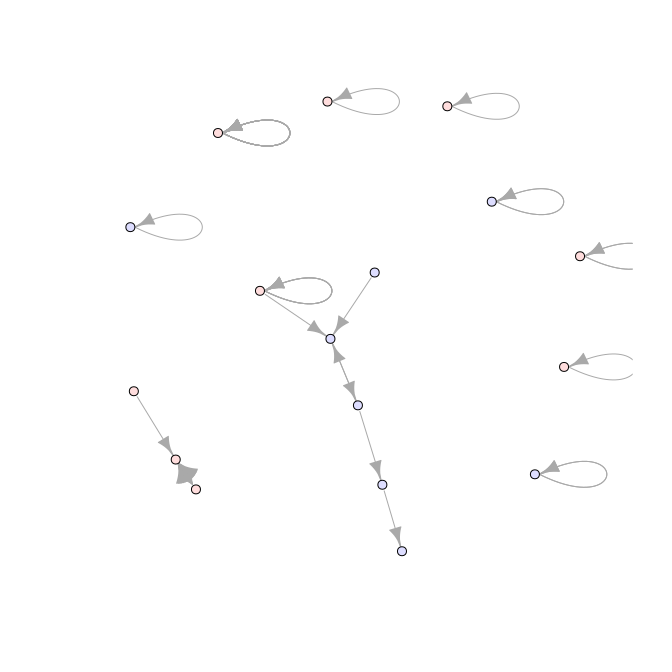

```r
if(nrow(usermentions.df) > 0){
  verts <- data.frame(
      name = vertex.query.df$screen_name,
      label = vertex.query.df$screen_name,
      title = vertex.query.df$name,
      color = vertex.query.df$color,
      stringsAsFactors = FALSE
  )

  for(n in names(verts)){
    g <- set_vertex_attr(g,n,value=verts[,n])
  }

  plot(
    g,
    vertex.color=vertex_attr(g,"color"),
    vertex.size=4,
    vertex.label=NA
  )
}
```

#### Interactive visualization with sigmajs

```r
# Not Run
if(nrow(usermentions.df) > 0){
  s <- sigmajs(height="1024px")
  s <- sg_from_igraph(s,g)
  s <- sg_settings(s,defaultEdgeColor="#EEE", edgeColor="default",minNodeSize=1,maxNodeSize=4)
  s
}
```

[interactive chart not shown]

#### Interactive visualization with visNetwork

```r
# Not Run
if(nrow(usermentions.df) > 0){
  g <- set_edge_attr(g,"title",E(g),paste(edge_attr(g,"created_at"),edge_attr(g,"status_text"),sep=": "))

  v <- visIgraph(g)
  v <- visEdges(
    v,
    color="gray"
  )
  v <- visNodes(
    v,
    size = 15
  )
  v
}
```

[interactive chart not shown]

### Retweet network analysis

This is a final network model, using the retweet network.

```r
retweet.query <- sprintf("SELECT query_users_retweeter.screen_name as retweeter,query_users_retweeted.screen_name as retweeted, status_retweet.id as status_id, status_retweet.text as retweet_text, status_original.text as original_text, status_retweet.created_at as created_at FROM query_users as query_users_retweeter JOIN status as status_retweet ON query_users_retweeter.user_id = status_retweet.user_id JOIN status as status_original ON status_retweet.retweet_status_id = status_original.id JOIN query_users as query_users_retweeted ON status_original.user_id = query_users_retweeted.user_id WHERE status_retweet.created_at > '%s' AND status_retweet.retweet = 1;",format(Sys.Date()-7))
retweets.df <- DBI::dbGetQuery(con,retweet.query)
if(nrow(retweets.df) > 0){
  g <- graph_from_data_frame(retweets.df)
  vertices.df <- data.frame(index=as.integer(V(g)), screen_name = names(V(g)),stringsAsFactors = FALSE)
  vertex.query <- sprintf("SELECT query_users.screen_name,query_users.party,query_users.body,user.name,user.location,user.description,user.followers_count,user.statuses_count FROM query_users JOIN user ON query_users.user_id = user.id WHERE query_users.screen_name IN (%s);",paste("'",vertices.df$screen_name,"'",sep="",collapse=","))
  vertex.query.df <- DBI::dbGetQuery(con,vertex.query)
  vertex.query.df <- vertex.query.df[match(vertices.df$screen_name,vertex.query.df$screen_name),]

  bluered <- function(party){
    if(tolower(party)=="democrat"){
      return("blue")
    } else if(tolower(party)=="republican"){
      return("red")
    } else {
      return("black")
    }
  }
  vertex.query.df$color <- sapply(vertex.query.df$party,bluered)
}
```

#### Eigenvector Centrality

```r
if(nrow(retweets.df) > 0){
  ec <- centr_eigen(g,directed=FALSE)
  df <- data.frame(
    Screen_Name = paste(
      "@",
      vertex.query.df$screen_name,
      sep=""
    ),
    Eig_Centrality = as.numeric(ec$vector)
  )
  df <- df[order(df[,2],decreasing=TRUE),]
  knitr::kable(
    df[1:10,],
    caption = "Retweet Network Eigenvector Centrality"
  )
}
```

#### Betweenness Centrality

```r
if(nrow(retweets.df) > 0){
  bc <- centr_betw(g,directed=FALSE)
  df <- data.frame(
    Screen_Name = paste(
      "@",
      vertex.query.df$screen_name,
      sep=""
    ),
    Bet_Centrality = as.numeric(bc$res)
  )
  df <- df[order(df[,2],decreasing=TRUE),]
  knitr::kable(
    df[1:10,],
    caption = "Retweet Network Betweenness Centrality"
  )
}
```

#### Visualize

```r
if(nrow(retweets.df) > 0){
  verts <- data.frame(
      name = vertex.query.df$screen_name,
      label = vertex.query.df$screen_name,
      title = vertex.query.df$name,
      color = vertex.query.df$color,
      stringsAsFactors = FALSE
  )

  for(n in names(verts)){
    g <- set_vertex_attr(g,n,value=verts[,n])
  }

  plot(g,vertex.color=vertex_attr(g,"color"),vertex.size=4,vertex.label=NA)
}
```

#### Interactive visualization with sigmajs

```r
# Not Run
if(nrow(retweets.df) > 0){
  s <- sigmajs()
  s <- sg_from_igraph(s,g)
  s <- sg_settings(s,defaultEdgeColor="#AAA", edgeColor="default",minNodeSize=1,maxNodeSize=4)
  s
}
```

#### Interactive visualization with visNetwork

```r
# Not Run
if(nrow(retweets.df) > 0){
  g <- set_edge_attr(g,"title",E(g),paste(edge_attr(g,"created_at"),edge_attr(g,"retweet_text"),sep=": "))

  v <- visIgraph(g)
  v <- visEdges(
    v,
    color="gray"
  )
  v <- visNodes(
    v,
    size = 15
  )
  v
}
```

# Way ahead

There are many more interesting analyses that could be done with this set. For example, do how to democrats’ and republicans’ sentiments vary when they use different hashtags or user mentions? Can we classify users as democrat or republican by their Twitter timelines? Hopefully, this package provides a useful toolset in collecting and analyzing Twitter data to answer questions like these.

## Don’t forget to disconnect!

```r
DBI::dbDisconnect(con)
```

```
#> [1] TRUE
```